# Forest plots for Handley et al. 2021 & 2022 length of stay studies

Heather H. Burris (with Nancy Yang and Anne Mullin)

2021-11-17

Associated papers:

- Handley et al. 2021: [Birth Hospital Length of Stay and Rehospitalization During COVID-19 | Pediatrics | American Academy of Pediatrics](https://publications-aap-org.proxy.library.upenn.edu/pediatrics/article/149/1/e2021053498/183458/Birth-Hospital-Length-of-Stay-and)
- Handley et al. 2022: [Postpartum Length of Stay and Hospital Readmission Before and During the Coronavirus Disease 2019 (COVID-19) Pandemic: Obstetrics & Gynecology](https://journals.lww.com/greenjournal/Fulltext/2022/03000/Postpartum_Length_of_Stay_and_Hospital_Readmission.5.aspx)

The original R code written by Heather Burris was adapted for this R Markdown file by Silvia Canelón.

The code chunks are hidden by default, but you can Show or Hide all code using the “Code” dropdown menu on the top right of this page. Or you can selectively view specific code chunks by clicking the “Code” buttons througout the page.

You can download this R Markdown file (.Rmd) by using the “Code” dropdown menu. You can also find the R Markdown file along with the original R script, data, and plot files organized in the Burris Lab Data Viz Resources folder. Each is organized according to the directory tree below.

- R Markdown file and the corresponding HTML file are found at the root of the folder “handley-LOS”
- Code is in the “code” folder
- Data are in the “data” folder”
- Plot files are in the “output” folder.

```
.
├── Burris-Lab/data-viz-resources
└── forest-plot
    └── handley-LOS
        ├── README.md
        ├── forest-plot-handley-LOS.Rmd
        ├── forest-plot-handley-LOS.html
        ├── code
        ├── data
        └── output
```

Detailed directory tree:

```
.
├── Burris-Lab/data-viz-resources
└── forest-plot
    └── handley-LOS
        ├── README.md
        ├── forest-plot-handley-LOS.Rmd
        ├── forest-plot-handley-LOS.html
        ├── code
        │   └── Maternal paper figures r code20211117.R
        ├── data
        │   ├── Data for Figure of mat readmit1121.csv
        │   └── dataforLMatLOS1121.csv
        └── output
            ├── PlotsSara_cosmos_fig_LOSONLY2noannote1.tiff
            ├── PlotsSara_cosmos_fig_MATERNALreadmitONLY2noannote1.tiff
            ├── bPlotsSara_cosmos_fig_MATERNALLOSONLY3withEE.tiff
            ├── cPlotsSara_cosmos_fig_MATERNALBOTH3withee.tiff
            └── cPlotsSara_cosmos_fig_MATERNALreadmitONLY3withee.tiff
```

## Setup

```r
xfun::pkg_attach("table1",
                 "ggplot2",
                 "dplyr",
                 "scales",
                 "grid",
                 "gridExtra",
                 "lattice",
                 "gtable",
                 "cowplot",
                 "here")

knitr::opts_chunk$set(echo = TRUE)

# define directory

# if you opened the R project file burris-lab-data-viz.Rproj:
dir <- here("forest-plot", "handley-LOS")

# if you're setting the working directory manually:

# getwd() to get the current working directory
# example output: "C:/Users/hhers/Dropbox"

# setwd() to set your working directory
# example:
# dir <- setwd("C:/Users/hhers/Dropbox/Burris Lab Data Viz Resources/forest-plot/handley-LOS")
```

## Short LOS

```r
LOSMAT.Fig <- read.csv(here(dir, "data", "dataforLMatLOS1121.csv"))

LOSMAT.Fig
```

```
##        Pop      Model combined   OR lower upper
## 1      All Unadjusted        1 1.99  1.97  2.02
## 2      All   Adjusted        2 2.35  2.32  2.39
## 3  Vaginal Unadjusted        3 1.91  1.88  1.94
## 4  Vaginal   Adjusted        4 2.14  2.11  2.18
## 5 Cesarean Unadjusted        5 2.25  2.21  2.30
## 6 Cesarean   Adjusted        6 2.90  2.83  2.98
```

```r
#View(LOSMAT.Fig)
```

```r
df1 <- data.frame(LOSMAT.Fig)
df1
```

```
##        Pop      Model combined   OR lower upper
## 1      All Unadjusted        1 1.99  1.97  2.02
## 2      All   Adjusted        2 2.35  2.32  2.39
## 3  Vaginal Unadjusted        3 1.91  1.88  1.94
## 4  Vaginal   Adjusted        4 2.14  2.11  2.18
## 5 Cesarean Unadjusted        5 2.25  2.21  2.30
## 6 Cesarean   Adjusted        6 2.90  2.83  2.98
```

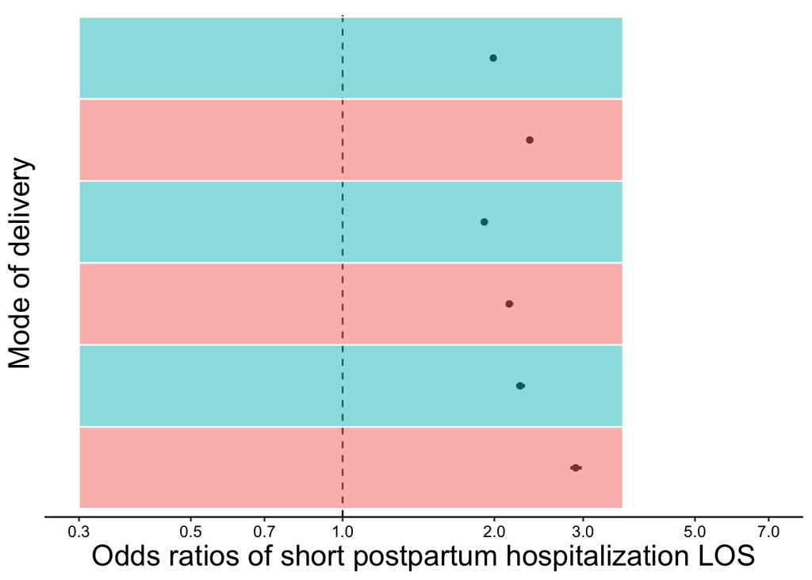

```r
df1$combined <- factor(
  df1$combined,
  levels=rev(df1$combined) # flips the order of the factors
  )
#df1 %>%
#  mutate(stripe = factor(ifelse(DOY %% 2 == 0, 1, 0))) %>%

# p1 ----
p1 <- ggplot(df1, aes(x=combined,
                      y=OR,
                      ymin=lower,
                      ymax=upper)) +
  geom_linerange(size=1,
                 col="black") +
  geom_hline(yintercept=1,
             lty=2) +
  geom_point(size=1.5,
             colour="black",
             stroke = 1.0,
             shape=16) +
  geom_rect(data=df1,
            colour="white",
            mapping=aes(
              xmin=as.numeric(combined)-0.5,
              xmax=as.numeric(combined)+0.5,
              ymin=0.3,
              ymax=3.6,
              fill=Model),
            alpha = 0.5)+
  # scale_fill_manual( = alpha(c("light blue", "red"), 0.2))+
  labs(
    y="Odds ratios of short postpartum hospitalization LOS",
    x="Mode of delivery")+
  scale_y_continuous(trans = "log10",
                     limits=c(0.3, 7),
                     n.breaks = 9) +
  theme_classic()+
  theme(
    #legend.title = element_blank(),
    #legend.text=element_text(size=11),
    legend.position = "none",
    axis.text.x = element_text(color = "black",
                               size =  10),
    axis.text.y = element_blank(),
    axis.title.x = element_text(color = "black",
                                size =  18),
    axis.title.y = element_text(color = "black",
                                size =  18),
    axis.line.y = element_blank(),
    axis.ticks.y = element_blank())+
  #axis.text.y = element_text(color = "black", size =  10)) +
  coord_flip()

p1
```

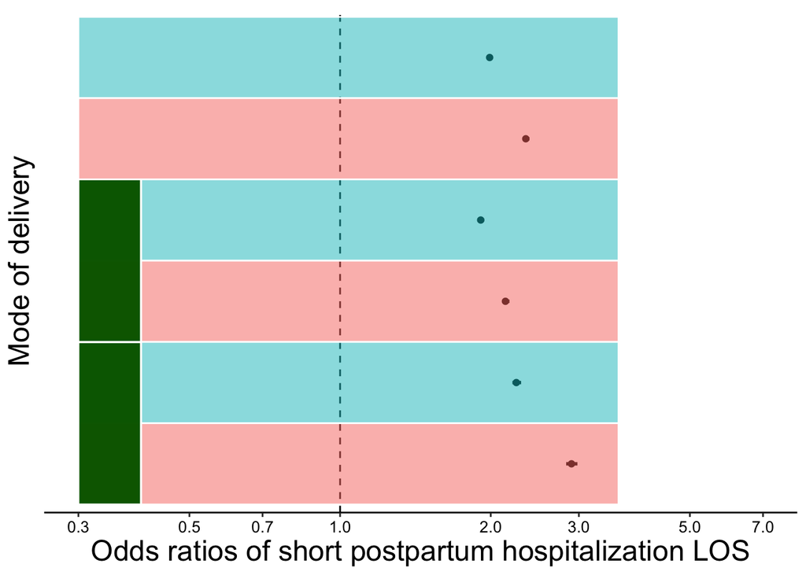

```r
#p1<-p1+scale_fill_brewer()
#p1<-p1+scale_fill_manual(values = alpha(c("light blue", "red"), .1))

# p1a ----
p1a<-p1+ geom_rect(data=df1, colour="white", mapping=aes(xmin= 0.5, xmax=2.5, ymin=0.3, ymax=0.4), fill="dark green", alpha =0.5)
#names(df1)

# p1b ----
p1b<-p1a+geom_rect(data=df1, colour="white", mapping=aes(xmin= 2.5, xmax=4.5, ymin=0.3, ymax=0.4), fill="dark green", alpha =0.5)

p1b
```

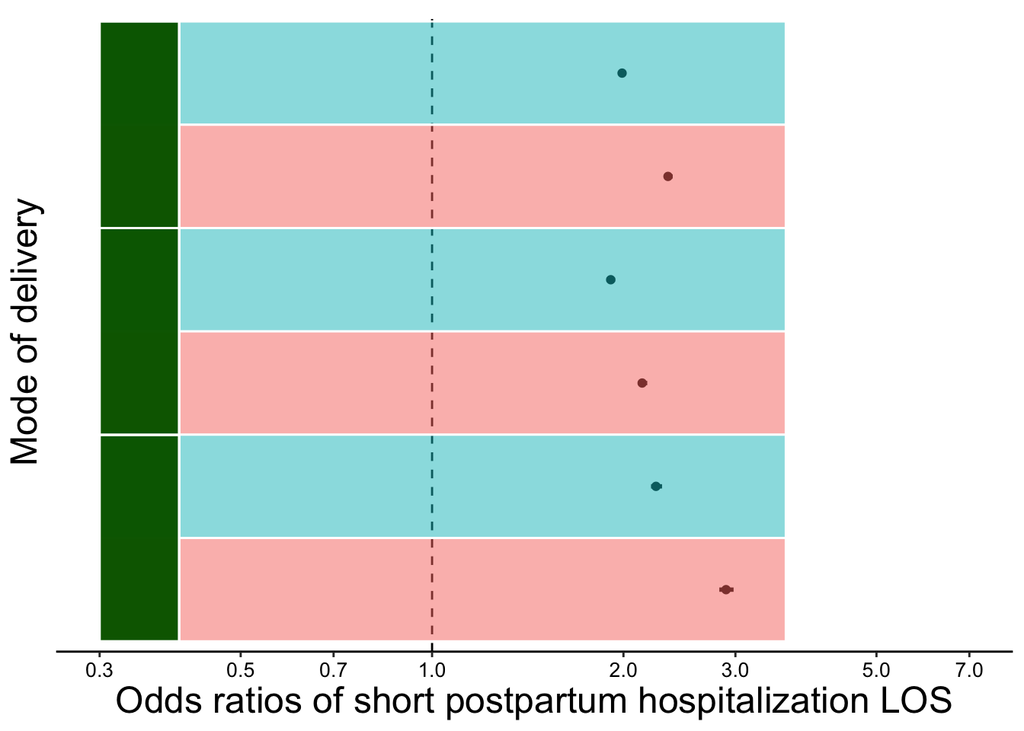

```r
# p1c ----
p1c <- p1b + geom_rect(data=df1,
                       colour="white",
                       mapping=aes(xmin= 4.5,
                                   xmax=6.5,
                                   ymin=0.3,
                                   ymax=0.4),
                       fill="dark green",
                       alpha =0.5)

p1c
```

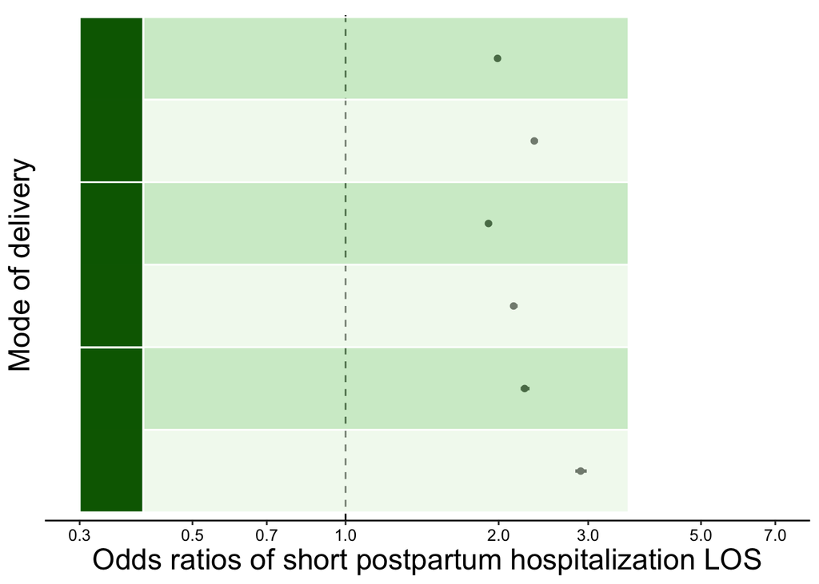

```r
p1c <- p1c + scale_fill_brewer(palette = "Greens")
p1c
```

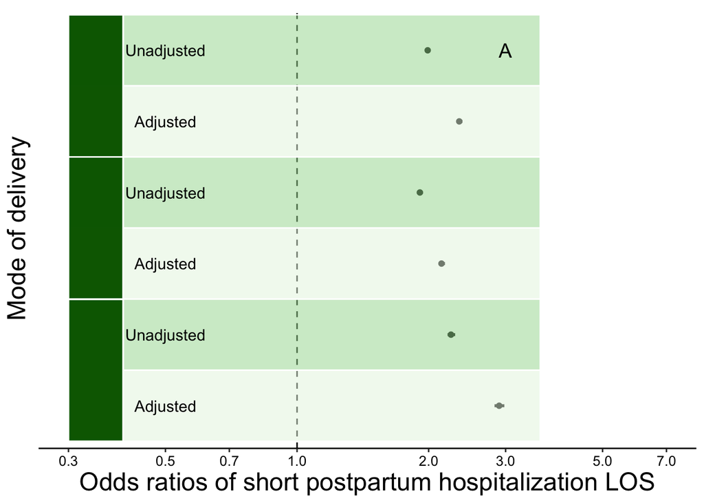

```r
p1c <- p1c + annotate(geom="text",
                      x=6.0,
                      y=3.0,
                      label="A",
                      size=5)
p1c <- p1c + annotate(geom="text",
                      x=6,
                      y=0.5,
                      label="Unadjusted",
                      size=4)
p1c <- p1c + annotate(geom="text",
                      x=5,
                      y=0.5,
                      label="Adjusted",
                      size=4)
p1c <- p1c + annotate(geom="text",
                      x=4,
                      y=0.5,
                      label="Unadjusted",
                      size=4)
p1c <- p1c + annotate(geom="text",
                      x=3,
                      y=0.5,
                      label="Adjusted",
                      size=4)
p1c <- p1c + annotate(geom="text",
                      x=2,
                      y=0.5,
                      label="Unadjusted",
                      size=4)
p1c <- p1c + annotate(geom="text",
                      x=1,
                      y=0.5,
                      label="Adjusted",
                      size=4)
p1c
```

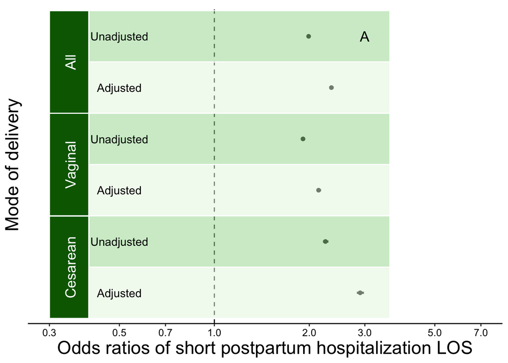

```r
# p1d ----
p1d <- p1c + annotate(geom="text",
                      x=5.5,
                      y=0.35,
                      label="All",
                      size=5,
                      colour="white",
                      angle=90)
p1d <- p1d+annotate(geom="text",
                    x=3.5,
                    y=0.35,
                    label="Vaginal",
                    colour="white",
                    size=5,
                    angle=90)
p1d <- p1d+annotate(geom="text",
                    x=1.5,
                    y=0.35,
                    label="Cesarean",
                    colour="white",
                    size=5,
                    angle=90)
p1d
```

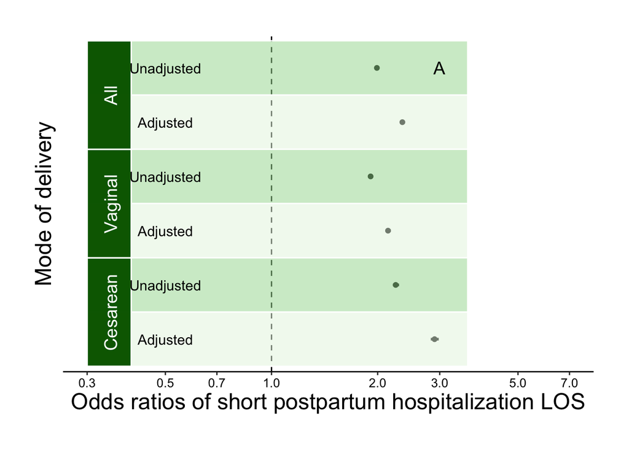

```r
p1d <- p1d + theme(plot.margin=unit(c(1,1,1,1),
                                    "cm")) #adding space to the bottom of the first grob (c(bottom,left,top,right))
p1d
```

### Maternal LOS, only 3 with EE

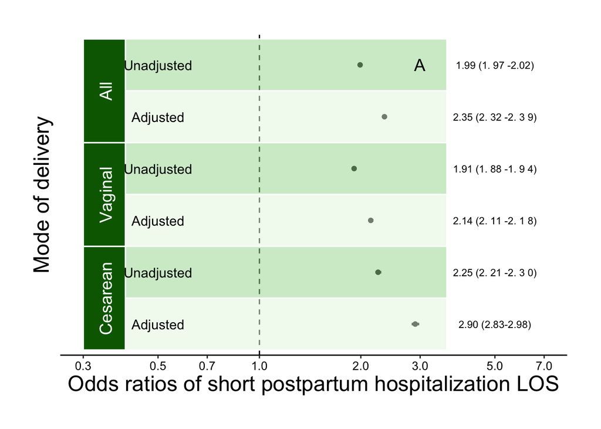

```r
## p1e ----
p1e <- p1d + annotate(geom="text",
                      x=6,
                      y=5,
                      label="1.99 (1. 97 -2.02)",
                      colour="black",
                      size=3)
p1e <- p1e + annotate(geom="text",
                      x=5,
                      y=5,
                      label="2.35 (2. 32 -2. 3 9)",
                      colour="black",
                      size=3)
p1e <- p1e + annotate(geom="text",
                      x=4,
                      y=5,
                      label="1.91 (1. 88 -1. 9 4)",
                      colour="black",
                      size=3)
p1e <- p1e + annotate(geom="text",
                      x=3,
                      y=5,
                      label="2.14 (2. 11 -2. 1 8)",
                      colour="black",
                      size=3)
p1e <- p1e + annotate(geom="text",
                      x=2,
                      y=5,
                      label="2.25 (2. 21 -2. 3 0)",
                      colour="black",
                      size=3)
p1e <- p1e + annotate(geom="text",
                      x=1,
                      y=5,
                      label="2.90 (2.83-2.98)",
                      colour="black",
                      size=3)
p1e
```

```r
ggsave(here(dir, "output", "bPlotsSara_cosmos_fig_MATERNALLOSONLY3withEE.tiff"),
       width=7.2,
       height=4.8,
       units= "in",
       device = "tiff",
       dpi=400,
       plot = p1e)
```

## Readmission figure

```r
readmitMAT.Fig <- read.csv(here(dir, "data", "Data for Figure of mat readmit1121.csv"))

readmitMAT.Fig
```

```
##        Pop      Model combined   OR lower upper
## 1      All Unadjusted        1 1.08  1.03  1.13
## 2      All   Adjusted        2 1.02  0.97  1.08
## 3  Vaginal Unadjusted        3 1.07  1.00  1.15
## 4  Vaginal   Adjusted        4 1.03  0.96  1.10
## 5 Cesarean Unadjusted        5 1.10  1.02  1.18
## 6 Cesarean   Adjusted        6 1.01  0.94  1.08
```

```r
# View(readmitMAT.Fig)
```

```r
df2 <- data.frame(readmitMAT.Fig)
df2
```

```
##        Pop      Model combined   OR lower upper
## 1      All Unadjusted        1 1.08  1.03  1.13
## 2      All   Adjusted        2 1.02  0.97  1.08
## 3  Vaginal Unadjusted        3 1.07  1.00  1.15
## 4  Vaginal   Adjusted        4 1.03  0.96  1.10
## 5 Cesarean Unadjusted        5 1.10  1.02  1.18
## 6 Cesarean   Adjusted        6 1.01  0.94  1.08
```

```r
df2$combined <- factor(df2$combined, levels=rev(df2$combined)) # flips the order of the factors
#df2 %>%
#  mutate(stripe = factor(ifelse(DOY %% 2 == 0, 1, 0))) %>%
```

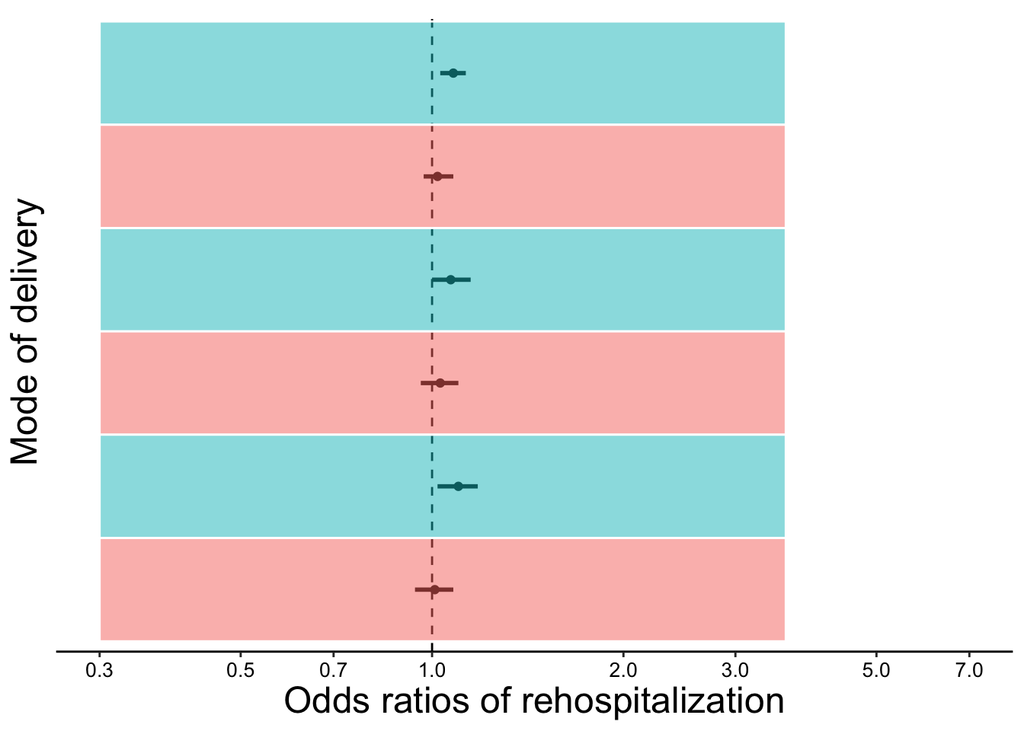

```r
# p2 ----
p2 <- ggplot(df2, aes(x=combined,
                      y=OR,
                      ymin=lower,
                      ymax=upper)) +
  geom_linerange(size=1,
                 col="black") +
  geom_hline(yintercept=1,
             lty=2) +
  geom_point(size=1.5,
             colour="black",
             stroke = 1.0,
             shape=16) +
  geom_rect(data=df2,
            colour="white",
            mapping=aes(xmin=as.numeric(combined)-0.5,
                        xmax=as.numeric(combined)+0.5,
                        ymin=0.3,
                        ymax=3.6,
                        fill=Model),
            alpha = 0.5)+
  # scale_fill_manual( = alpha(c("light blue", "red"), 0.2))+
  labs(y="Odds ratios of rehospitalization",
       x="Mode of delivery")+
  scale_y_continuous(trans = "log10",
                     limits=c(0.3, 7),
                     n.breaks = 9) +
  theme_classic()+
  theme(
    #legend.title = element_blank(),
    #legend.text=element_text(size=11),
    legend.position = "none",
    axis.text.x = element_text(color = "black",
                               size =  10),
    axis.text.y = element_blank(),
    axis.title.x = element_text(color = "black",
                                size =  18),
    axis.title.y = element_text(color = "black",
                                size =  18),
    axis.line.y = element_blank(),
    axis.ticks.y = element_blank())+
  #axis.text.y = element_text(color = "black", size =  10)) +
  coord_flip()
#p2<-p2+scale_fill_brewer()
#p2<-p2+scale_fill_manual(values = alpha(c("light blue", "red"), .1))
p2
```

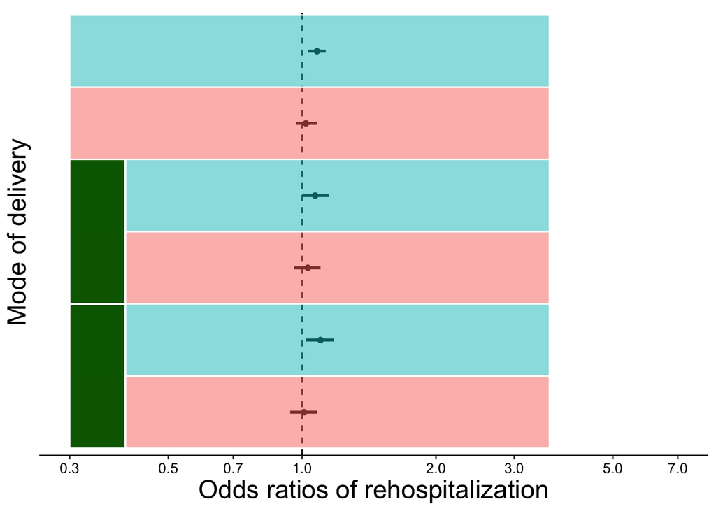

```r
# p2a ----
p2a<-p2+ geom_rect(data=df2,
                   colour="white",
                   mapping=aes(xmin= 0.5,
                               xmax=2.5,
                               ymin=0.3,
                               ymax=0.4),
                   fill="dark green",
                   alpha =0.5)
#names(df2)

# p2b ----
p2b<-p2a+geom_rect(data=df2,
                   colour="white",
                   mapping=aes(xmin= 2.5,
                               xmax=4.5,
                               ymin=0.3,
                               ymax=0.4),
                   fill="dark green",
                   alpha =0.5)

p2b
```

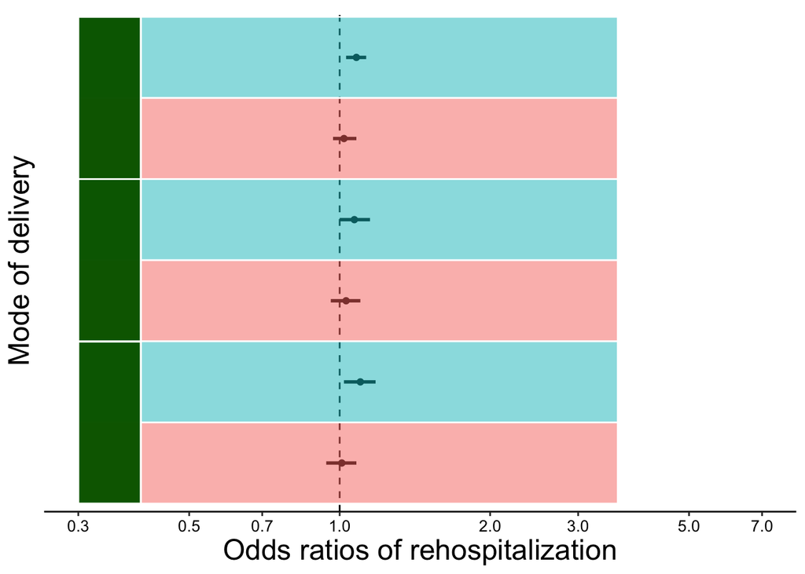

```r
# p2c ----
p2c <- p2b+geom_rect(data=df2,
                     colour="white",
                     mapping=aes(xmin= 4.5,
                                 xmax=6.5,
                                 ymin=0.3,
                                 ymax=0.4),
                     fill="dark green",
                     alpha =0.5)

p2c
```

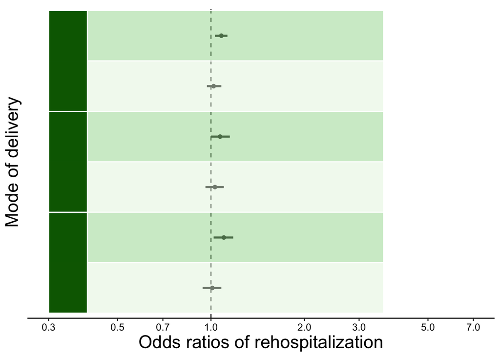

```r
p2c <- p2c+scale_fill_brewer(palette = "Greens")
p2c
```

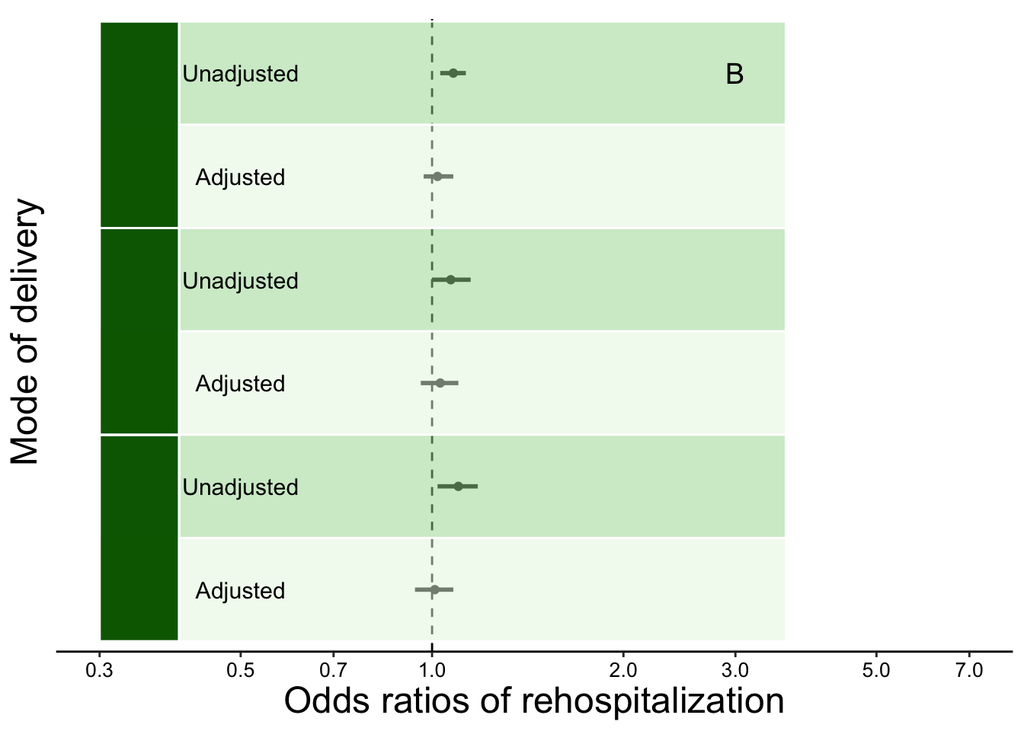

```r
p2c <- p2c + annotate(geom="text",
                      x=6.0,
                      y=3.0,
                      label="B",
                      size=5)
p2c <- p2c+ annotate(geom="text",
                     x=6,
                     y=0.5,
                     label="Unadjusted",
                     size=4)
p2c <- p2c+ annotate(geom="text",
                     x=5,
                     y=0.5,
                     label="Adjusted",
                     size=4)
p2c <- p2c+ annotate(geom="text",
                     x=4,
                     y=0.5,
                     label="Unadjusted",
                     size=4)
p2c <- p2c+ annotate(geom="text",
                     x=3,
                     y=0.5,
                     label="Adjusted",
                     size=4)
p2c <- p2c+ annotate(geom="text",
                     x=2,
                     y=0.5,
                     label="Unadjusted",
                     size=4)
p2c <- p2c+ annotate(geom="text",
                     x=1,
                     y=0.5,
                     label="Adjusted",
                     size=4)
p2c
```

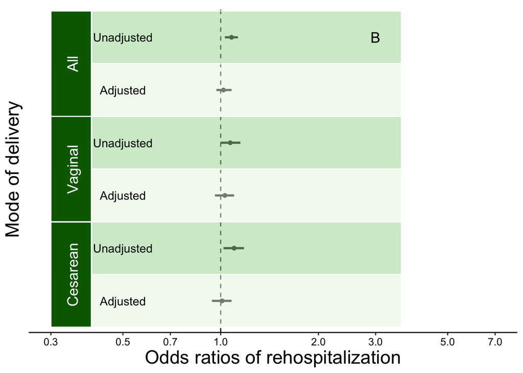

```r
# p2d ----
p2d <- p2c + annotate(geom="text",
                      x=5.5,
                      y=0.35,
                      label="All",
                      size=5, colour="white",
                      angle=90)
p2d <- p2d + annotate(geom="text",
                      x=3.5,
                      y=0.35,
                      label="Vaginal",
                      colour="white",
                      size=5,
                      angle=90)
p2d <- p2d + annotate(geom="text",
                      x=1.5,
                      y=0.35,
                      label="Cesarean",
                      colour="white",
                      size=5,
                      angle=90)
p2d
```

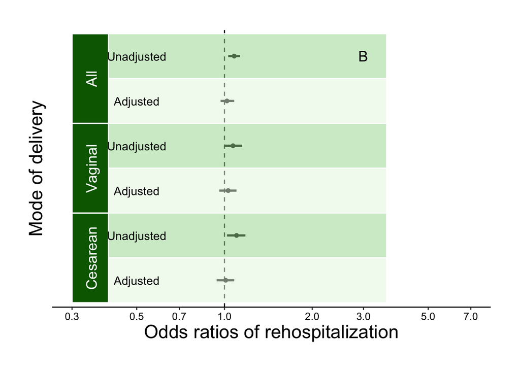

```r
p2d = p2d + theme(plot.margin=unit(c(1,1,1,1),"cm")) #adding space to the bottom of the first grob (c(bottom,left,top,right))
p2d
```

### Maternal readmit, only 3 with EE

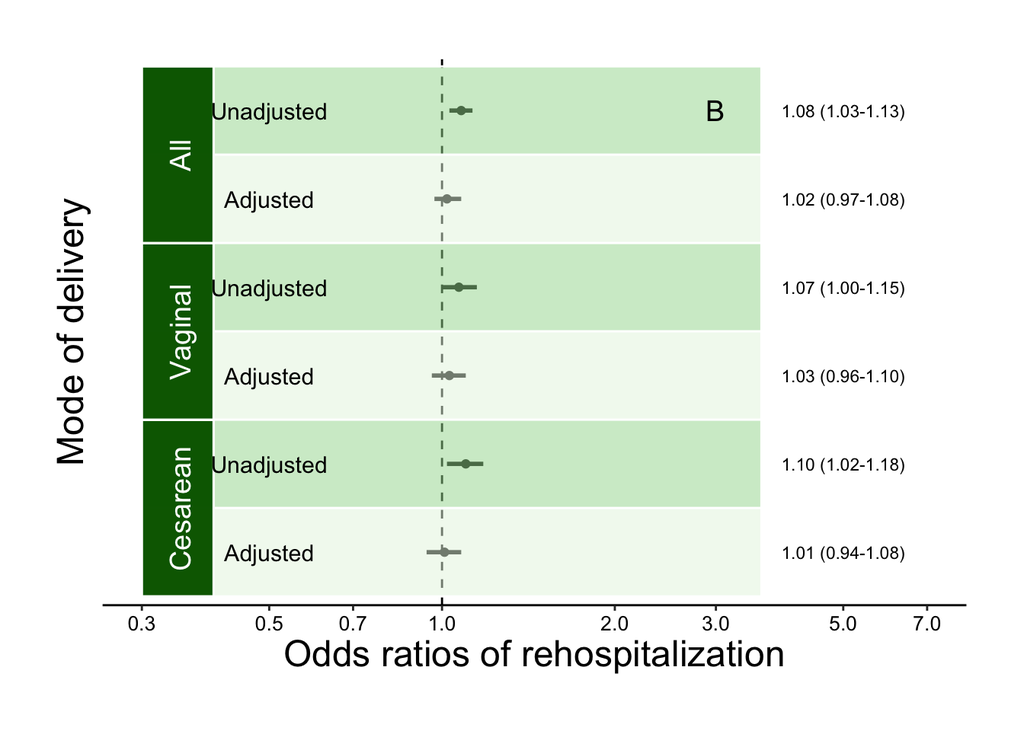

```r
# p2e ----
p2e <- p2d + annotate(geom="text",
                      x=6,
                      y=5,
                      label="1.08 (1.03-1.13)",
                      colour="black",
                      size=3)
p2e <- p2e + annotate(geom="text",
                      x=5,
                      y=5,
                      label="1.02 (0.97-1.08)",
                      colour="black",
                      size=3)
p2e <- p2e + annotate(geom="text",
                      x=4,
                      y=5,
                      label="1.07 (1.00-1.15)",
                      colour="black",
                      size=3)
p2e <- p2e + annotate(geom="text",
                      x=3,
                      y=5,
                      label="1.03 (0.96-1.10)",
                      colour="black",
                      size=3)
p2e <- p2e + annotate(geom="text",
                      x=2,
                      y=5,
                      label="1.10 (1.02-1.18)",
                      colour="black",
                      size=3)
p2e <- p2e + annotate(geom="text",
                      x=1,
                      y=5,
                      label="1.01 (0.94-1.08)",
                      colour="black",
                      size=3)
p2e
```

```r
ggsave(here(dir, "output", "cPlotsSara_cosmos_fig_MATERNALreadmitONLY3withee.tiff"),
       width=7.2,
       height=4.8,
       units= "in",
       device = "tiff",
       dpi=400,
       plot = p2e)
```

### Maternal, both 3 with EE

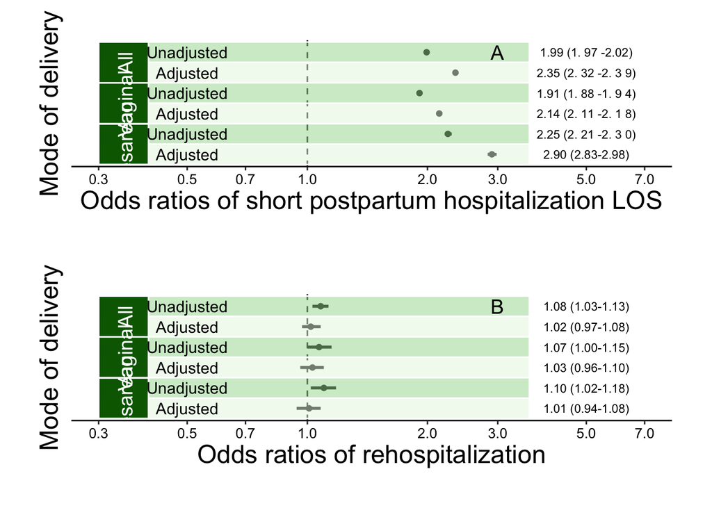

```r
# p1e + p2e ----

# arranging the grobs
both <-grid.arrange(
  p1e,
  p2e,
  ncol = 1,
  nrow = 2,
  heights = c(4, 4),
  clip = FALSE
)
```

```r
both
```

```r
#saving as tiff (can save as any file type here)
ggsave(here(dir, "output", "cPlotsSara_cosmos_fig_MATERNALBOTH3withee.tiff"),
       width=7.2,
       height=9.6,
       units= "in",
       device = "tiff",
       dpi=400,
       plot = both)
getwd()
```

```
## [1] "/Users/scanelon/Sync/Repos/1-Projects/Burris-Lab/data-viz-resources/forest-plot/handley-LOS"
```

## No annotation

### Maternal LOS, only 2

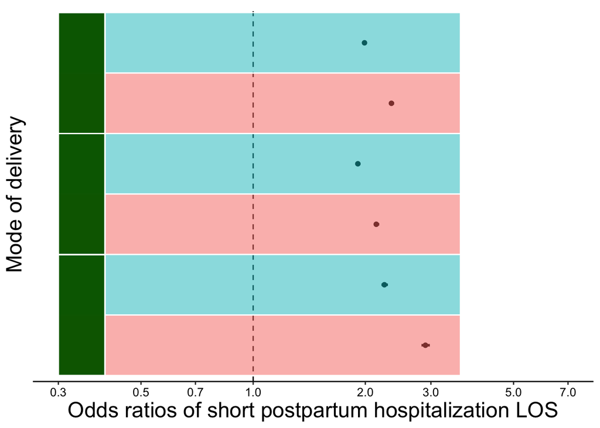

```r
# p1c ----
p1c <- p1b + geom_rect(data=df1,
                       colour="white",
                       mapping=aes(xmin= 4.5,
                                   xmax=6.5,
                                   ymin=0.3,
                                   ymax=0.4),
                       fill="dark green",
                       alpha =0.5)

p1c
```

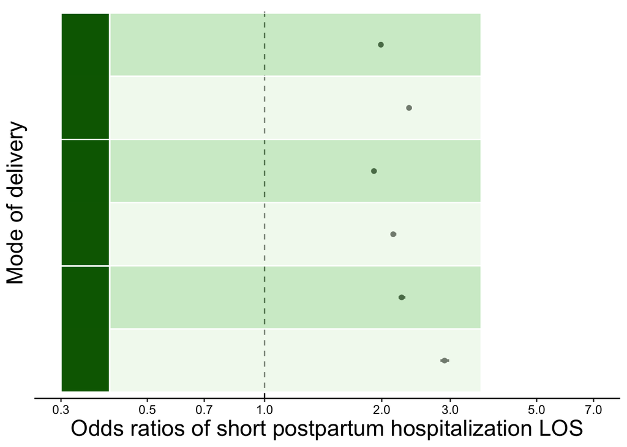

```r
p1c <- p1c + scale_fill_brewer(palette = "Greens")
p1c
```

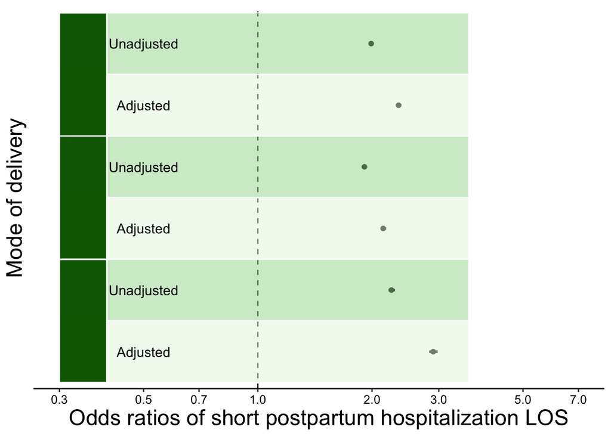

```r
#p1c <- p1c + annotate(geom="text", x=6.0,  y=3.0, label="A", size=5)
p1c <- p1c+ annotate(geom="text",
                     x=6,
                     y=0.5,
                     label="Unadjusted",
                     size=4)
p1c <- p1c+ annotate(geom="text",
                     x=5,
                     y=0.5,
                     label="Adjusted",
                     size=4)
p1c <- p1c+ annotate(geom="text",
                     x=4,
                     y=0.5,
                     label="Unadjusted",
                     size=4)
p1c <- p1c+ annotate(geom="text",
                     x=3,
                     y=0.5,
                     label="Adjusted",
                     size=4)
p1c<-p1c+ annotate(geom="text",
                   x=2,
                   y=0.5,
                   label="Unadjusted",
                   size=4)
p1c<- p1c+ annotate(geom="text",
                    x=1,
                    y=0.5,
                    label="Adjusted",
                    size=4)
p1c
```

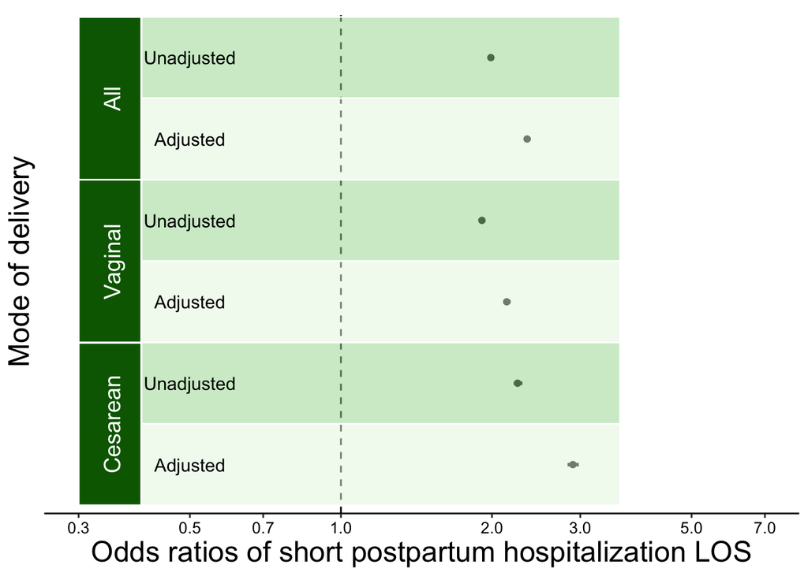

```r
# p1d ----
p1d<-p1c+annotate(geom="text",
                  x=5.5,
                  y=0.35,
                  label="All",
                  size=5,
                  colour="white",
                  angle=90)
p1d<-p1d+annotate(geom="text",
                  x=3.5,
                  y=0.35,
                  label="Vaginal",
                  colour="white",
                  size=5,
                  angle=90)
p1d<-p1d+annotate(geom="text",
                  x=1.5,
                  y=0.35,
                  label="Cesarean",
                  colour="white",
                  size=5,
                  angle=90)
p1d
```

```r
p1d <- p1d + theme(plot.margin=unit(c(1,1,1,1),"cm")) #adding space to the bottom of the first grob (c(bottom,left,top,right))

ggsave(here(dir, "output", "PlotsSara_cosmos_fig_LOSONLY2noannote1.tiff"),
       width=7.2,
       height=4.8,
       units= "in",
       device = "tiff",
       dpi=400,
       plot = p1d)
```

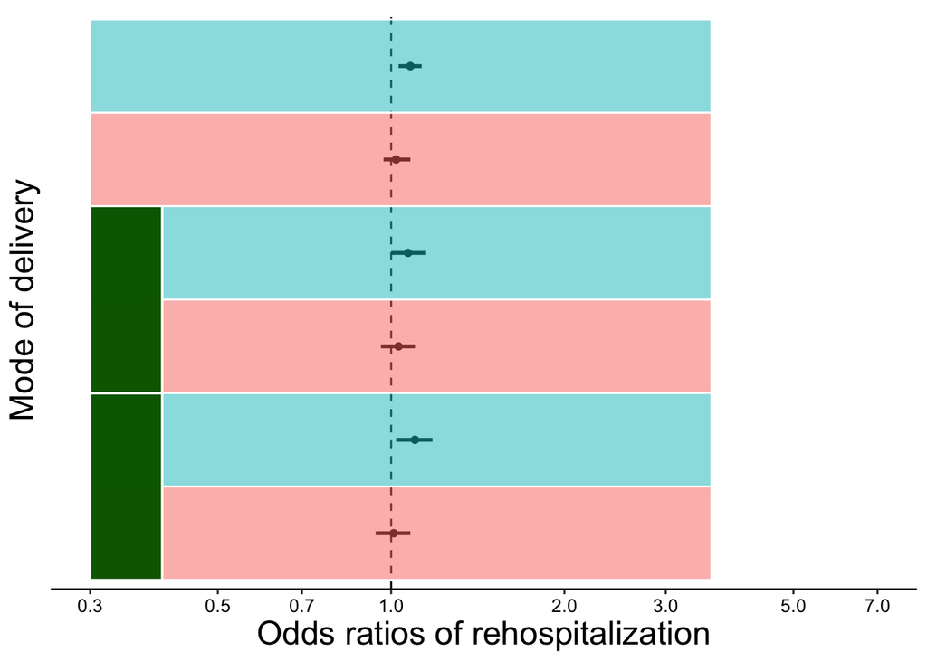

```r
# p2c ----
p2b
```

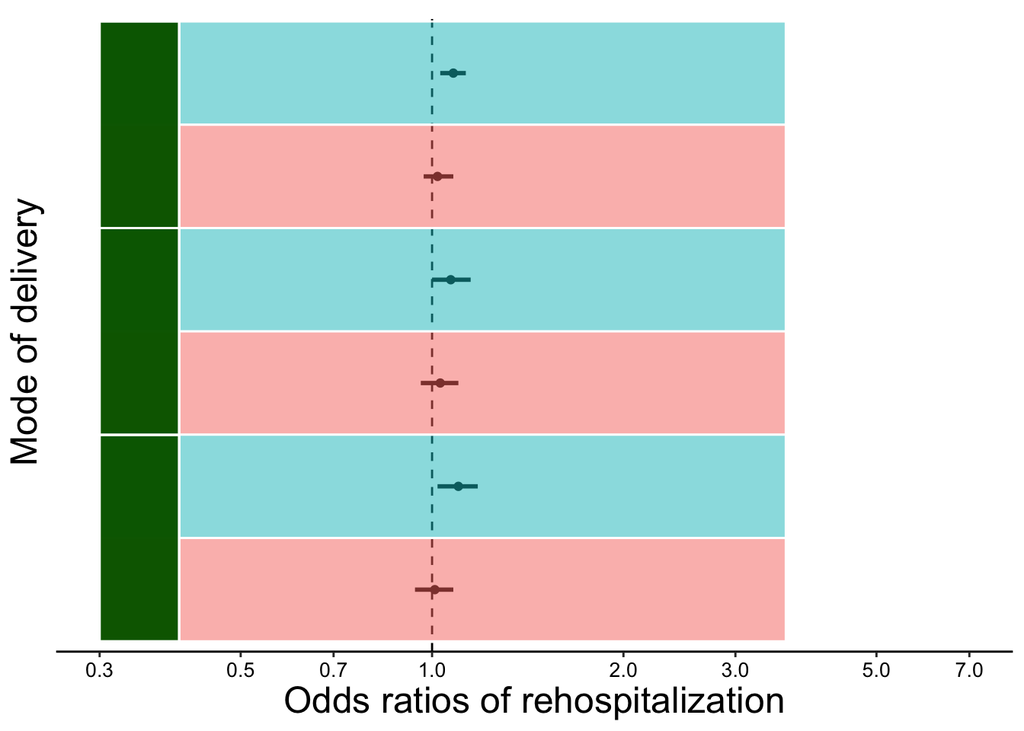

```r
p2c <- p2b + geom_rect(data=df2,
                       colour="white",
                       mapping=aes(xmin= 4.5,
                                   xmax=6.5,
                                   ymin=0.3,
                                   ymax=0.4),
                       fill="dark green",
                       alpha =0.5)

p2c
```

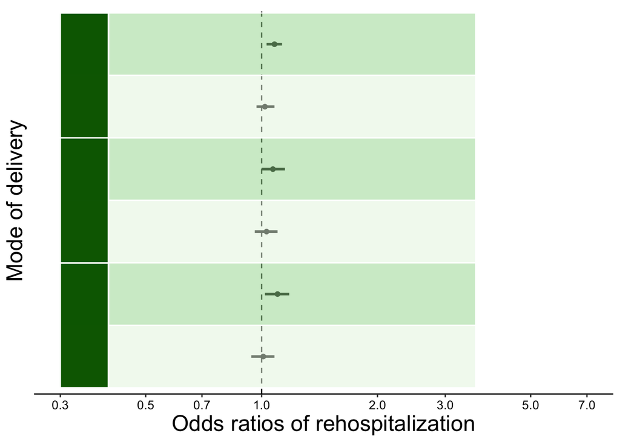

```r
p2c <- p2c + scale_fill_brewer(palette = "Greens")
p2c
```

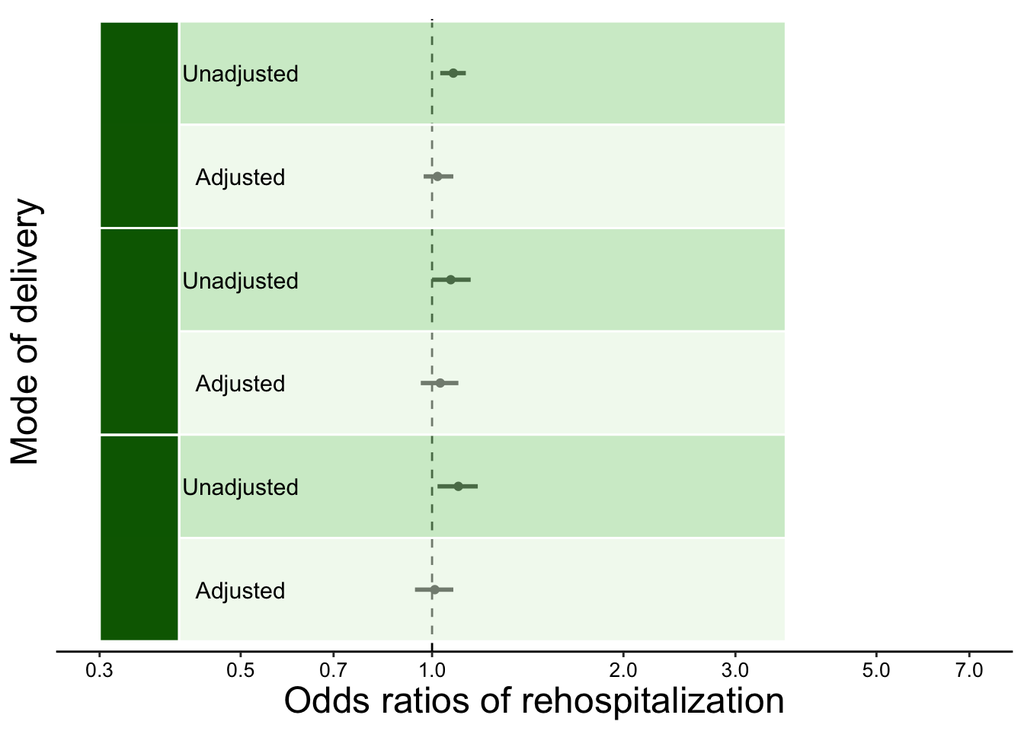

```r
#p2c <- p2c + annotate(geom="text", x=6.0,  y=3.0, label="B", size=5)
p2c <- p2c + annotate(geom="text",
                      x=6,
                      y=0.5,
                      label="Unadjusted",
                      size=4)
p2c <- p2c + annotate(geom="text",
                      x=5,
                      y=0.5,
                      label="Adjusted",
                      size=4)
p2c <- p2c + annotate(geom="text",
                      x=4,
                      y=0.5,
                      label="Unadjusted",
                      size=4)
p2c <- p2c + annotate(geom="text",
                      x=3,
                      y=0.5,
                      label="Adjusted",
                      size=4)
p2c <- p2c + annotate(geom="text",
                      x=2,
                      y=0.5,
                      label="Unadjusted",
                      size=4)
p2c <- p2c + annotate(geom="text",
                      x=1,
                      y=0.5,
                      label="Adjusted",
                      size=4)
p2c
```

### Maternal readmit, only 2

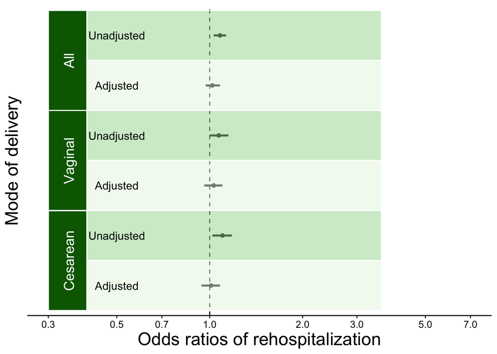

```r
# p2d ----
p2d<-p2c+annotate(geom="text",
                  x=5.5,
                  y=0.35,
                  label="All",
                  size=5,
                  colour="white",
                  angle=90)
p2d<-p2d+annotate(geom="text",
                  x=3.5,
                  y=0.35,
                  label="Vaginal",
                  colour="white",
                  size=5,
                  angle=90)
p2d<-p2d+annotate(geom="text",
                  x=1.5,
                  y=0.35, label="Cesarean",
                  colour="white",
                  size=5,
                  angle=90)
p2d
```

```r
p2d = p2d + theme(plot.margin=unit(c(1,1,1,1),"cm")) #adding space to the bottom of the first grob (c(bottom,left,top,right))

ggsave(here(dir, "output", "PlotsSara_cosmos_fig_MATERNALreadmitONLY2noannote1.tiff"),
       width=7.2,
       height=4.8,
       units= "in",
       device = "tiff",
       dpi=400,
       plot = p2d)

# getwd()
```